# Chapter Two

Ryan B. Honea

## Exercise One

#### Question

We want to test whether there is any difference in yield between the two groups. Let $Y_{jk}$ denote the $k$th observation in the $j$th group where $j = 1$ for the treatment group, $j = 2$ for the control group and $k = 1,...,20$ for both groups. Assume that the $Y_{jk}$’s are independent random variables with $Y_{jk} \sim \text{N}(\mu_j, \sigma^2)$. The null hypothesis $H_0: \mu_1 = \mu_2 = \mu$, that there is no differenc, is to be compared with the alternative hypothesis $H_1 : \mu_1 \neq \mu_2$.

**(a):** Conduct a exploratory analysis of the data looking at the distributions for each group (e.g. using dot plots, stem and leaf plots or Normal probability plots) and calculate summary statistics (e.g., means, medians, standard derivations, maxima and minima). What can you infer from these investigations?

**(b):** Perform an unpaired t-test on these data and calculate a 95% confidence interval for the difference between the group means. Interpret these results.

**(c):** The following models can be used to test the null hypothesis $H_0$ against the alternative hypothesis $H_1$, where
$$\begin{align*}
H_0 : E(Y_{jk}) &= \mu;\quad Y_{jk} \sim \text{N}(\mu, \sigma^2),\\
H_1 : E(Y_{jk}) &= \mu_j;\quad Y_{jk} \sim \text{N}(\mu_j, \sigma^2),
\end{align*}$$

for $j = 1,2$ and $k = 1,...,20$. Find the maximum likelihood and least squares estimate of the parameters $\mu, \mu_1, \mu_2$ assuming $\sigma^2$ is a known constant.

**(d):** Show that the minimum values of the least squares criteria area
$$\begin{align*}
\text{for } H_0, \quad \hat{S_0} &= \sum \sum (Y_{jk} - \overline{Y})^2, \text{ where } \overline{Y} = \sum_{j=1}^2\sum_{k=1}^K Y_{jk}/40;\\
\text{for } H_1, \quad \hat{S_1} &= \sum \sum (Y_{jk} - \overline{Y_j})^2, \text{ where } \sum_{k=1}^K Y_{jk}/40;
\end{align*}$$

for $j = 1,2$.

**(e):** Using the results of (d) show that
$$\frac{1}{\sigma^2}\hat{S_1} = \frac{1}{\sigma^2}\sum_{j=1}^2\sum_{k=1}^{20}(Y_{jk} - \mu_j)^2 - \frac{20}{\sigma^2}\sum^{20}_{k=1}(\overline{Y_j} - \mu_j)^2,$$
and deduce that if $H_1$ is true
$$\frac{1}{\sigma^2}\hat{S_1} \sim \chi^2(38).$$
Similarly show that
$$\frac{1}{\sigma^2}\hat{S_0} = \frac{1}{\sigma^2}\sum_{j=1}^2\sum_{k=1}^{20}(Y_{jk} - \mu)^2 - \frac{40}{\sigma^2}\sum_{j=1}^2(\overline{Y} - \mu)^2$$
and if $H_0$ is true then
$$\frac{1}{\sigma^2}\hat{S_0} \sim \chi^2(39).$$

**(f):** Use an argument similar to the one in Example 2.2.2 and the results from (e) to deduce that the statistic
$$F = \frac{\hat{S_0} - \hat{S_1}}{\hat{S_1}/38}$$
has the central $F$-distribution $F(1,38)$ if $H_0$ is true and a non-central distribution if $H_0$ is not true.

**(g):** Calculate the $F$-statistic from (f) and use it to test $H_0$ against $H_1$. What do you conclude?

**(h):** Compare the value of $F$-statistic from (g) with the t-statistic from (b), recalling the relationship between the $t$-distribution and the $F$-distribution (see Section 1.4.4). Also compare the conclusion from (b) and (g).

**(i):** Calculate residuals from the model for $H_0$ and use them to explore the distributional assumptions.

#### Solution

**(a):** I’ll begin by making a histogram of the joint data from treatment and control, followed by an Anderson Darling test to assess the normality of the joint set of data.

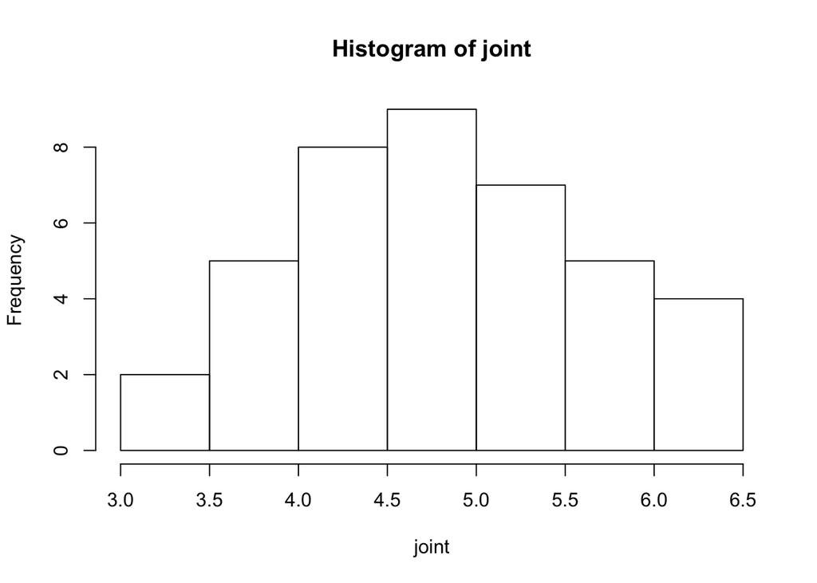

```
##
##  Anderson-Darling normality test
##
## data:  joint
## A = 0.15921, p-value = 0.9456
```

Let $Y_jk$ denote the weight of the $k$th man at the $j$th time, where $j = 1$ before the program and $j = 2$ twelve months later. Assume the $Y_{jk}$’s are independent random variables $Y_{jk} \sim N(\mu_j, \sigma^2)$ for $j = 1,2$ and $k = 1,...,20$.

**(a):** Use an unpaired t-test to test the hypothesis
$$H_0 : \mu_1 = \mu_2 \quad \text{versus} \quad H_1: \mu_1 \neq \mu_2.$$

**(b):** Let $D_k = Y_{1k} - Y_{2k}$, for $k = 1,...,20$. Formulate models for testing $H_0$ against $H_1$ using the $D_k$’s. Using analogous methods to Exercise 2.1 above, assuming $\sigma^2$ is a known constant, test $H_0$ against $H_1$.

**(c):** The analysis in (b) is a paired t-test which uses the natural relationship between weights of the *same* person before and after the program. Are the conclusions the same from (a) and (b)?

**(d):** List the assumptions made for (a) and (b). Which analysis is more appropriate for these data?

## Exercise Five

THe model for two-factor analysis of variance with two levels of one factor, three levels of the other ad no replication is
$$\text{E}(Y_{jk}) = \mu_{jk} = \mu + \alpha_j + \beta_{k}; \quad \quad Y_{jk} \sim \text{N}(\mu_{jk}, \sigma^2),$$
where $j = 1,2; k = 1,2,3$ and, using the sum-to-zero constraints, $\alpha_1 + \alpha_2 = 0, \beta_1 + \beta_2 = 0$. Also the $Y_{jk}’s are assumed to be independent.

Write the equation for $\text{E}(Y_{jk})$ in matrix notation. (Hint: Let $\alpha_2 = -\alpha_1$ and $\beta_3 = -\beta_1 - \beta_2$)